# A probability puzzle

Zheng Gao

Jan 9, 2019

I was asked the following question during an interview. It is documented here because it reminded me of the difference of 0-1 loss and Hamming loss again.

#### *“Three players each flip a fair coin independently, observing the outcome of the other two players’ but not his own. No communication is allowed. Each player may opt to guess the outcome of his own coin. They win (as a group) if all guesses are correct. (And lose if no player makes an attempt, or if an incorrect guess is made among all who attempted.) What is a strategy that makes the probability of winning greater than 50%?”*

For example, players might decide to guess Tails all the time. They would win if all of them get Tails (with probability 1/8), but lose otherwise. Alternatively, they may decide that one of them should make a guess while the other two look on idle. Since only one of them attempts, the probability of winning is 1/2.

Since the coin flips are fair and independent, conditioning on the outcomes of the other players provides no information on his own. The heart of a good strategy must therefore lie in the entry criteria, i.e., when to make an attempt.

Notice that the winning criteria take on the form of a 0-1 loss, and penalizes one incorrect guess just as much as many. The entry criteria of a good strategy should therefore make incorrect guesses collide, and correct guesses disjoint.

(If the loss function was Hamming, it would be impossible to exceed, or drop below 50%.)

### Solution

Here is an (optimal) solution:

*“On observing two of the same kind from the other two players, opt to guess the opposite of their outcome. E.g., guess Tail when the other two playes’ outcomes are Heads.”*

It is easy to check that the players win whenever there are exactly two of the same kind, i.e., HHT or TTH. In such cases only the player with the minority outcome would make a (correct) guess. The probability of winning is the same as the probability of HHT or TTH happening, or $3/4$.

### Optimality

I was told that smart people were able to solve the puzzle in under a minute. I’m not in that category (and unsuprisingly failed the interview). Nevertheless, the interviewer himself was not aware of the optimaility of the constructed solution.

Optimality stems from the following argument.

If player i attempts a guess with probability $p_i$, the probability of his guess being correct, by indenpendence, is $p_i/2$. Since the group would lose if any one of them makes a mistake, the probability of winning is no bigger than $1-p_i/2$.

On the other hand, the probability of winning cannot be bigger than the sum of each player guessing correctly, $(p_1+p_2+p_3)/2$ — at least one of them must make it right.

The optimal propensity of participation is therefore at $p_i=1/2$, with probability of winning $3/4$. This happens to be attained by the strategy detailed above.

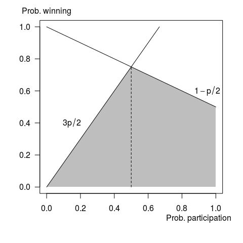

Solving the linear program in R.

```r
if (!(require("lpSolve"))) {
  install.packages("lpSolve")
  library("lpSolve")
}
f.obj <- c(1, 0, 0, 0)
f.con <- matrix (c(1, 1/2, 0, 0,
                   1, 0, 1/2, 0,
                   1, 0, 0, 1/2,
                   1, -1/2, -1/2, -1/2), nrow=4, byrow=TRUE)
f.dir <- rep("<=", 4)
f.rhs <- c(1, 1, 1, 0)
sol <- lp("max", f.obj, f.con, f.dir, f.rhs)
sol$solution
```

```
[1] 0.75 0.50 0.50 0.50
```

### Generalizations

The interviewer told me that there exist solutions for games played with different numbers of players. (Although he did not know the solutions.) Here I state some generalizations.

Observe that the solution to the original 3-player-problem tries to predict “balanced” outcomes, so that the most common outcomes are covered with correct guesses. Indeed, balanced coins tend to produce roughly equal number of Heads and Tails.

Extending this idea, we have a strategy for the 5-player-game that does better than 50%.

*“On observing exactly three of the same kind from the other four players, opt to guess the minority outcome. E.g., guess Tail when three other playes’ outcomes are Heads, and one other player hits Tail.”*

Since the group wins whenver HHHTT or TTTHH happens, the probability of winning is at least (in fact, exactly)

```r
2 * choose(5, 3) / 2^5
```

```
[1] 0.625
```

And for the 7-player-game.

*“On observing exactly four of the same kind from the other six players, opt to guess the minority outcome. E.g., guess Tail when four other playes’ outcomes are Heads, and two other players hit Tails.”*

```r
2 * choose(7, 4) / 2^7
```

```
[1] 0.546875
```

This kind of entension stop at 7 players, as the strategies only guarantee wins at the modes of the game outcomes (see Figure below). As the number of players increase, by the DeMoivre-Laplace approximation, the modes no longer occupy enough mass.

```r
barplot(choose(7, 0:7), names.arg = 0:7, las = 1,
        col = c(rep("grey", 3), rep("grey61", 2), rep("grey", 3)))
mtext(text = "Total number of Heads in an outcome", side = 1, line = 2, at = 7)
```

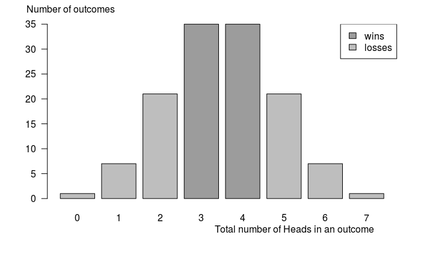

```r
mtext(text = "Number of outcomes", side = 3, line = 0.8, at = 0.5)
legend("topright", legend = c("wins","losses"), fill = c("grey61","grey"))
```

The simple bounds used in the previous section to show optimality are no longer sufficient here. The optimality of the strategies in these extensions are unknown to me.